# Introduction to Econometrics with R

## Measures of fit

After estimating a linear regression the question occurs how well that regression line describes the data. Are the observations tightly clustered arround the regression line, or are they spread out? The $R^2$ and the standard error of the regression (**SER**) measure how well the OLS Regression line fits the data.

### The $R^2$

The $R^2$ is the fraction of sample variance of $Y_i$ explained by $X_i$. Mathemethically, the $R^2$ can be written as the explained sum of squares to the total sum of squares. The **explained sum of squares** (**ESS**) is the sum of squared deviations of the predicted values, $\hat{Y_i}$, from the average of $Y_i$. The **total sum of squares**(**TSS**) is the sum of squared deviations of $Y_i$ from its average.

$$\begin{align}
ESS & = \sum_{i = 1}^n \left( \hat{Y_i} - \bar{Y} \right)^2 \\
\\
TSS & = \sum_{i = 1}^n \left( Y_i - \bar{Y} \right)^2 \\
\\
R^2 & = \frac{ESS}{TSS}
\end{align}$$

### Standard Error of the Regression

The **Standard Error of the Regression** (**SER**) is an estimator of the standard deviation of the regression error $\hat{u_i}$.
$$SER = s_{\hat{u} } \text{, where } s_{\hat{u} }^2 = \frac{1}{n-2} \sum_{i = 1}^n \hat{u_i ^2} = \frac{SSR}{n - 2}$$

## Application to the test score data

Both measures of fit can be obtained by using the function `summary()` with the `lm` object as the only argument. Whereas `lm()` only prints out the coefficients, `summary()` provides additional predefined information such as the $R^2$ and the **SER**.

```r
summary(linear_model)
```

```
##
## Call:
## lm(formula = score ~ tsratio, data = CASchools)
##
## Residuals:
##     Min      1Q  Median      3Q     Max
## -47.727 -14.251   0.483  12.822  48.540
##
## Coefficients:
##             Estimate Std. Error t value Pr(>|t|)
## (Intercept) 698.9329     9.4675  73.825  < 2e-16 ***
## tsratio      -2.2798     0.4798  -4.751 2.78e-06 ***
## ---
## Signif. codes:  0 '***' 0.001 '**' 0.01 '*' 0.05 '.' 0.1 ' ' 1
##
## Residual standard error: 18.58 on 418 degrees of freedom
## Multiple R-squared:  0.05124,    Adjusted R-squared:  0.04897
## F-statistic: 22.58 on 1 and 418 DF,  p-value: 2.783e-06
```

The $R^2$ in the output is called multiple R-squared and takes the value $0.051$. Hence, $5.1 \%$ of the variance of the dependent variable *TestScore* is explained by the explanatory variable *STR*. That is the regression explains some of the variance but much of the variation of *TestScore* remains unexplained (compare figure 4.3).

The **SER** is called residual standard error and takes the value 18.58. The unit of the **SER** is the same as the unit of the dependent variable. We interpret the **SER** as follows: on average the deviation of the actual achieved *TestScore* and the regression line is 18.58 points.

# 4.4 The Least Square Assumptions

### Key Concept 4.3

### The Least Square Assumptions

$$Y_i = \beta_0 + \beta_1 X_i + u_i \text{, } i = 1, ...,n \text{, where}$$

1. The error term $u_i$ has conditional mean zero given $X_i$: $E(u_i|X_i) = 0$
2. $(X_i,Y_i), i = 1,...,n$ are independent and identically distributed (i.i.d.) draws from their joint distribution
3. Large outliers are unlikely: $X_i$ and $Y_i$ have nonzero finite fourth moments

## Error Term has conditional mean of zero

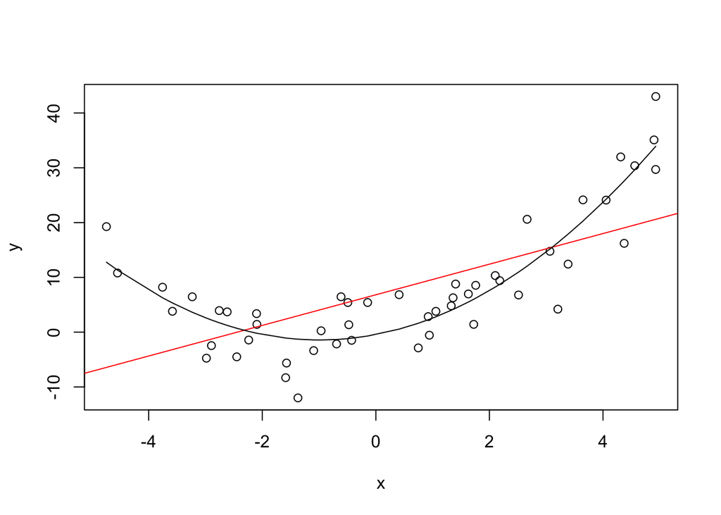

```r
set.seed(321)
x <- runif(50, -5, 5)
u <- rnorm(50, sd = 5)
y <- x^2 + 2*x + u
plot(y~x)

l <- predict(lm(y~x +  I(x^2)), data.frame(x = sort(x)))
abline(lm(y~x), col = "red")
lines(sort(x), l)
```

## Sensitivity to Outliers

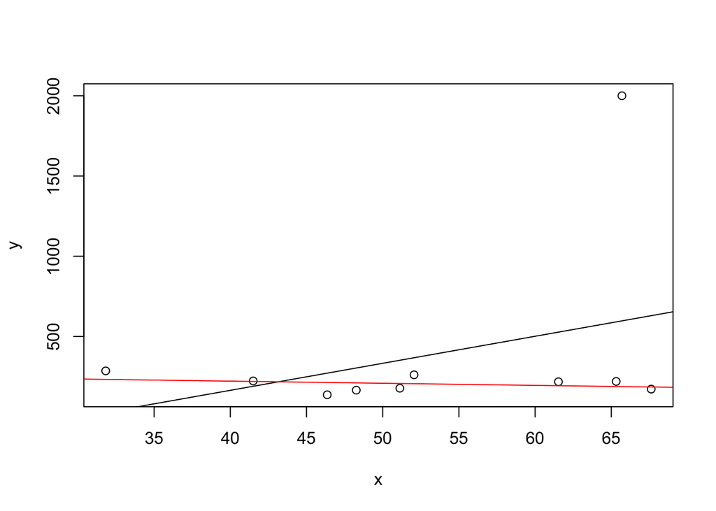

```r
set.seed(123)
x     <- sort(runif(10, min = 30, max = 70 ))
y     <- rnorm(10 , mean = 200, sd = 50)
y[9] <- 2000

fit               <- lm(y ~ x)
fitWithoutOutlier <- lm(y[-9] ~ x[-9])

plot(y ~ x)
abline(fit)
abline(fitWithoutOutlier, col = "red")
```

```r
library(ggvis)
library(dplyr)

set.seed(123)
x     <- sort(runif(15, min = 30, max = 70 ))
y     <- rnorm(15 , mean = 200, sd = 50)
df    <- data.frame(y, x)

v <- input_slider(0, 250, value = 0, step = 25, animate = TRUE)
outlier <- function(y, v) y + c(rep(0, 14), v)

df %>%
  ggvis(x = ~x, y = ~y)  %>%
  mutate(y = outlier(y, eval(v))) %>%
  layer_points() %>%
  layer_model_predictions(model  = "lm", formula = y ~ x)
```

# 4.5 The Sampling Distribution of the OLS Estimator

Because the OLS estimators $\hat{\beta_0}$ and $\hat{\beta_1}$ are computed from a randomly drawn sample, the estimators themselves are random variables with a probability distribution -the sampling distribution- that describes the values they could take over different random samples. Although the sampling distribution of $\hat{\beta_0}$ and $\hat{\beta_1}$ can be complicated when the sample size is small, it is possible to make certain statements about it that hold for all $n$. In particular
$$E(\hat{\beta_0}) = \beta_0 \text{ and } E(\hat{\beta_1}) = \beta_1,$$
that is, $\hat{\beta_0}$ and $\hat{\beta_1}$ are unbiased estimators of $\beta_0$ and $\beta_1$. If the sample is sufficiently large, by the central limit theorem the sampling distribiution of the estimators is well approximated by the bivariate normal distribution. This implies that the marginal distributions are also normal in large samples.

### Key Concept 4.4

### Large Sample Distribution of $\hat{\beta_0}$ and $\hat{\beta_1}$

If the least square assumption in Key Concept 4.3 hold, then in large-samples $\hat{\beta_0}$ and $\hat{\beta_1}$ have a jointly normal sampling distribution. The large-sample normal distribution of $\hat{\beta_1}$ is $N(\beta_1, \sigma^2_\hat{\beta_1})$, where the variance of the distribution, $\sigma^2_\hat{\beta_1}$, is

$$\sigma^2_\hat{\beta_1} = \frac{1}{n} \frac{var \left[ \left(X_i - \mu_X \right) u_i \right]} {\left[ var \left(X_i \right) \right]^2}$$

The large-sample normal distribution of $\hat{\beta_0}$ is $N(\beta_0, \sigma^2_\hat{\beta_0})$, where
$$\sigma^2_\hat{\beta_0} = \frac{1}{n} \frac{var \left( H_i u_i \right)}{ \left[ E \left(H_i^2 \right) \right]^2 }\text{, where } H_i = 1 - \left[ \frac{\mu_X} {E \left( X_1^2\right)} \right] X_i.$$

Whether this really holds we can verify using R. First we build our own population of $1000$ observations in total (n_pop). To do this we need values for our independent variable $x$, for the error term $u$, and the regression parameters $\beta_0$ and $\beta_1$. With all this we can also compute our dependent variable $y$. In our example we generate the numbers $x_i$, $i = 1$, … ,$1000$ by drawing a random sample from a uniform distriburion in the range $[0,20]$. The realisations of the error term $u_i$, $i = 1$, … ,$1000$ are drawn from a standard distribution with $\mu = 0$ and $\sigma^2 = 100$ (note that `rnorm()` requires $\sigma$ as input). Furthermore we chose $\beta_0 = -2$ and $\beta_1 = 3.5$.

```r
#Population Regression
pop_n      <- 1000
x          <- runif(pop_n, min = 0, max = 20)
u          <- rnorm(pop_n, sd = 10)
y          <- -2 + 3.5*x + u
population <- data.frame(x, y)
```

From now on we will consider the previously generated data as the truth (which we of course would not know in a real world example). This knowledge about the true relationship between $y$ and $x$ can be used to verify the statements of key concept 4.4. Now let us assume that we do not know the true values for $\beta_0$ and $\beta_1$ and we also can not observe the whole population. However, we can observe a random sample of 100 observations. Using OLS it would be possible to estimate $\beta_0$ and $\beta_1$. However, the estimates would depend on which observations of the population we have drawn and it is very unlikly that 2 sample of 100 observation would result in the same parameter estimates.

To do so we first calculate the variances $\sigma^2_\hat{\beta_0}$ and $\sigma^2_\hat{\beta_1}$.

```r
n <- 100 # sample size
sigma_b1 <- var( ( x - mean(x) ) * u ) / (100 * var(x)^2)
H_i      <- 1 - mean(x) / mean(x^2) * x
sigma_b0 <- var(H_i * u) / (n * mean(H_i^2)^2 )

#Estimation
number_of_estimations <- 500


fit <- matrix(ncol = 2, nrow = number_of_estimations)
for (i in 1:number_of_estimations){
 random_sample  <- population[ sample(1:pop_n, n), ]
 fit[i, ]       <- lm(y ~ x, data = random_sample)$coefficients
}

var(fit[ ,1])
```

```
## [1] 3.896125
```

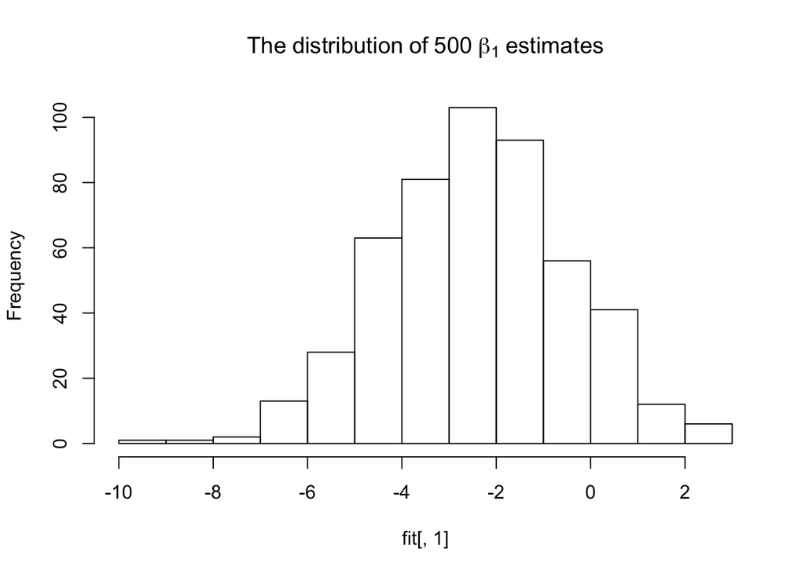

```r
hist(fit[ ,1], main = bquote(The ~ distribution  ~ of ~ 500 ~ beta[1] ~ estimates))
```

```r
var(fit[ ,2])
```

```
## [1] 0.03054151
```

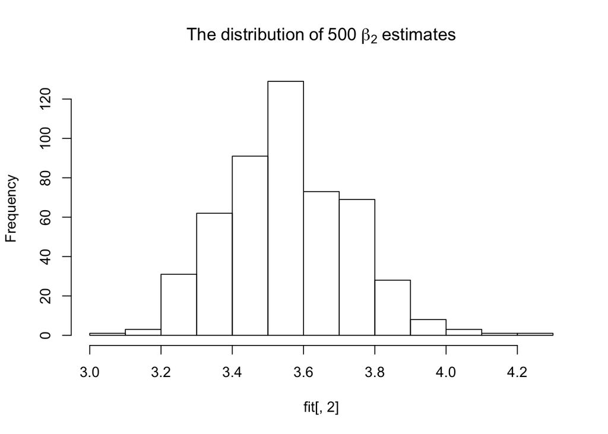

```r
hist(fit[ ,2], , main = bquote(The ~ distribution  ~ of ~ 500 ~ beta[2] ~ estimates))
```

# Chapter 5

In this chapter, we continue with the treatment of the simple linear regression model. We will see how we may use our knowledge about the sampling distribution of the OLS estimator in order to make statements regarding its uncertainty.  
This chapter covers:

- Testing Hypotheses about regression coefficients
- Confidence intervals for regression coefficients
- Regression when $X$ is a dummy variable
- Heteroskedasticity and Homoskedasticity

## Section 5.1 Two-Sided Hypotheses Concerning $\beta_1$

Using the fact that $\hat{\beta}_1$ is approximately normal distributed in large samples, hypothesis testing about the true value $\beta_1$ can be done with the same approach as discussed in chapter 3.2.

### Key Concept 5.1

### General Form of the $t$-Statistic

Remember from section 3.2 that a general $t$-statistic has the form

$$t = \frac{\text{estimated value} - \text{hypothesized value}}{\text{standard error of the estimator}}.$$

### Key Concept 5.2

### Testing Hyothesis about $\beta_1$

For testing the hypothesis $H_0: \beta_1 = \beta_{1,0}$, we need to perform the following steps:

1. Compute the standard error of $\hat{\beta}_1$, $SE(\hat{\beta}_1)$

$$SE(\hat{\beta}_1) = \sqrt{ \hat{\sigma}^2_{\hat{\beta}_1} } \ \ , \ \
\hat{\sigma}^2_{\hat{\beta}_1} = \frac{1}{n} \times \frac{\frac{1}{n-2} \sum_{i=1}^n (X_i - \overline{X})^2 \hat{u_i}^2 }{ \left[ \frac{1}{n} \sum_{i=1}^n (X_i - \overline{X})^2 \right]^2}$$

2. Compute the $t$-statistic.

$$t = \frac{\hat{\beta}_1 - \beta_{1,0}}{ SE(\hat{\beta}_1) }$$

3. Reject at the $5\%$ level if $|t^{act}| > 1.96$ or, equivalently, if the $p$-value is less than 0.05.
   $$p \text{-value} = \text{Pr}_{H_0} \left[ \left| \frac{ \hat{\beta}_1 - \beta_{1,0} }{ SE(\hat{\beta}_1) } \right| > \left| \frac{ \hat{\beta}_1^{act} - \beta_{1,0} }{ SE(\hat{\beta}_1) } \right| \right] = \text{Pr}_{H_0} (|t| > |t^{act}|) = 2 \Phi(-|t^{act}|)$$
   The last equality holds due to the normal approximation.

How can we get these values using R? By looking at the second column of the coefficients’ summary, we discover both values. In the third column, we find $t^{act}$ for tests of hypotheses $H_0: \beta_0=0$ and $H_0: \beta_1=0$. Furthermore we find corresponding $p$-values in the fourth column.

```r
summary(linear_model)$coefficients
```

```
##               Estimate Std. Error   t value      Pr(>|t|)
## (Intercept) 698.932949  9.4674911 73.824516 6.569846e-242
## tsratio      -2.279808  0.4798255 -4.751327  2.783308e-06
```

Let’s have a closer look at the test $H_0: \beta_1=0 \, v. \, H_1: \beta_1 \neq 0$. Using our revisited knowledge about $t$-statistics we see that

$$t^{act} = \frac{-2.279808 - 0}{0.4798255} \approx - 4.75$$

What does this tell about the significance of the estimated coefficient? Using R we may visualise how such a statement can be made:

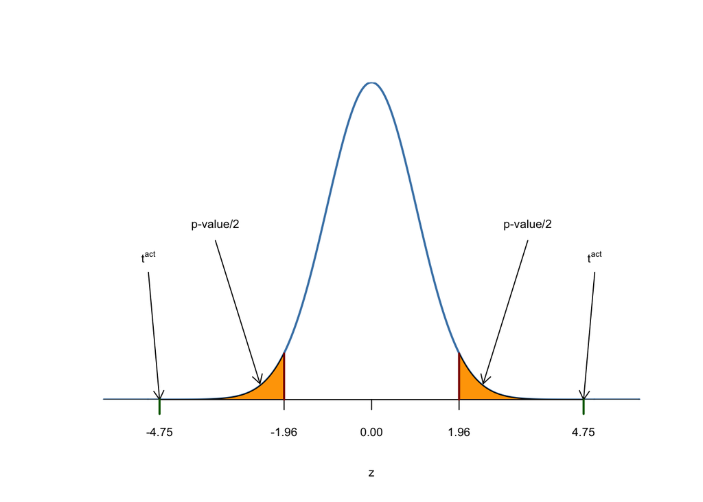

```r
# Plot the standard normal density
z <- seq(-6,6,0.01)
tact <- -4.75
plot(z, dnorm(z,0,1), type = "l", col="steelblue", lwd=2, yaxs="i", bty = "n", axes=F, ylab = "", cex.lab=0.7)
axis(1, at = c(0,-1.96,1.96,-tact,tact), cex.axis=0.7)

# Shade the critical regions
polygon(c(-6,seq(-6,-1.96,0.01),-1.96),c(0,dnorm(seq(-6,-1.96,0.01)),0),col='orange')
polygon(c(1.96,seq(1.96,6,0.01),6),c(0,dnorm(seq(1.96,6,0.01)),0),col='orange')

# Add arrows and text indicating critical regions and the p-value
arrows(-3.5,0.2,-2.5,0.02, length = 0.1)
arrows(3.5,0.2,2.5,0.02, length = 0.1)

arrows(-5,0.16,-4.75,0, length = 0.1)
arrows(5,0.16,4.75,0, length = 0.1)

text(-3.5,0.22, labels = "p-value/2", cex = 0.7)
text(3.5,0.22, labels = "p-value/2", cex = 0.7)

text(-5,0.18, labels = expression(t^{act}), cex = 0.7)
text(5,0.18, labels = expression(t^{act}), cex = 0.7)

# Add ticks indicating critical values at the 0.05-level, t^act and -t^act
rug(c(-1.96,1.96), ticksize  = 0.145, lwd = 2, col = "darkred")
rug(c(-tact,tact), ticksize  = -0.0451, lwd = 2, col = "darkgreen")
```

## Section 5.2 Confidence Intervals for Regression Coefficients

As we already know, estimates of regression coefficients $\beta_0$ and $\beta_1$ have sampling uncertainty. Therefore, we will never estimate the exact true value of these parameters from sample data. However, we may construct confidence intervals for the intercept and the slope parameter.

### Key Concept 5.3

### Confidence Interval for $\beta_i$

Imagine you could draw all possible random samples of given size. The interval that contains the true value $\beta_i$ in $95\%$ of all samples is given by the expression

$$\text{KI}_{0.95}^{\beta_i} = \left[ \hat{\beta}_i - 1.96 \times SE(\hat{\beta}_i) \, , \, \hat{\beta}_i + 1.96 \times SE(\hat{\beta}_i) \right].$$

Equivalently, this interval can be seen as the set of null hypotheses for which a $5\%$ two-sided hypothesis test cannot reject.

Let us now turn back to the regression model stored in `linear_model`. An easy way to get $95\%$ confidence intervals for $\beta_0$ and $\beta_1$ is to use the function `confint()`. We only have to provide a fitted model object as an argument.

```r
confint(linear_model)
```

```
##                 2.5 %     97.5 %
## (Intercept) 680.32312 717.542775
## tsratio      -3.22298  -1.336636
```

Let us check if the calculation is done as we expect it to be. For $\beta_1$, according to the formula presented above, interval borders are computed as

$$-2.279808 \pm 1.96 \times 0.4798255 \, \Rightarrow \, \text{KI}_{0.95}^{\beta_1} = \left[ -3.22, -1.34 \right]$$

so this actually leads to the same interval. Obviously, this interval does not contain zero what, as we have already seen in section 5.1, leads to rejection of the null hypothesis $\beta_{1,0} = 0$.

## Section 5.3 Regression when X is Binary

Instead of using a continuous regressor $X$, we might be interested in running the regression

$$Y_i = \beta_0 + \beta_1 D_i + u_i$$

where $D_i$ is binary variable or so-called *dummy variable*. For example, we define $D_i$ in the following way:

$$D_i = \begin{cases}
1 \ \ \text{if $stratio$ in $i^{th}$ district < 20} \\
0 \ \ \text{if $stratio$ in $i^{th}$ district $\geq$ 20} \\
\end{cases}$$

The regression model now is

$$score_i = \beta_0 + \beta_1 D_i + u_i.$$

Let us see how these data points look like.

[figure not shown]

```r
# Create the dummy variable as defined above
for (i in 1:nrow(CASchools)) {
  if (CASchools$tsratio[i] < 20) {
    CASchools$D[i] <- 1
    } else {
      CASchools$D[i] <- 0
    }
  }

# Plot the data
plot(CASchools$D, CASchools$score,
     pch=20, cex=0.5 ,col="Steelblue",
     xlab=expression(D[i]), ylab="Test Score",
     main = "Dummy Regression"
     )
```

We see that it is not useful to think of $\beta_1$ as a slope parameter since $D_i \in \{0,1\}$, i.e. we only observe two discrete values instead of continuous regressor values lying (in some range) on the real line. Simply put, there is no continuous line depicting the conditional expectation function $E(score | D_i)$ since this function is solely defined for positions $0$ and $1$.

The interpretation of estimated coefficients from such a regression model is as follows:

We will now use R to estimate the dummy regression.

```r
dummy_model <- lm(score ~ D, data = CASchools)
summary(dummy_model)
```

```
##
## Call:
## lm(formula = score ~ D, data = CASchools)
##
## Residuals:
##     Min      1Q  Median      3Q     Max
## -50.496 -14.029  -0.346  12.884  49.504
##
## Coefficients:
##             Estimate Std. Error t value Pr(>|t|)
## (Intercept)  650.077      1.393 466.666  < 2e-16 ***
## D              7.169      1.847   3.882  0.00012 ***
## ---
## Signif. codes:  0 '***' 0.001 '**' 0.01 '*' 0.05 '.' 0.1 ' ' 1
##
## Residual standard error: 18.74 on 418 degrees of freedom
## Multiple R-squared:  0.0348, Adjusted R-squared:  0.0325
## F-statistic: 15.07 on 1 and 418 DF,  p-value: 0.0001202
```

One can see that the expected test score in districts with $tsratio < 20$ ($D_i = 1$) is predicted to be $650.1 + 7.17 = 657.27$ while districs with $tsratio \geq 20$ ($D_i = 0$) are expected to have an average test score of only $650.1$.

Group specific predictions can be added to the plot by execution of the following code chunk.

```r
points(CASchools$D, predict(dummy_model), col="red", pch=20)
```

The red dots represent group averages in the sample. Accordingly, $\hat{\beta}_1$ can be seen as the difference in group averages.

By inspection of the output generated with `summary(dummy_model)` we may also find an awnser to the question wether there is a significant difference in group means. This can be assessed by a (two-tailed) test of the hypothesis $H_0: \beta_1 = 0$ for which the $t$-statistic and the corresponding $p$-value are computed defaultly by `summary()`.

Equivalently, we may use the `confint()` function to compute a $95\%$ confidence interval for the true difference in means and see if the hypothesised value is element of this set.

```r
confint(dummy_model)
```

```
##                  2.5 %    97.5 %
## (Intercept) 647.338594 652.81500
## D             3.539562  10.79931
```

We reject the hypothesis at the $5\%$ significance level since $\beta_{1,0} = 0$ lies outside of the interval $[3.54, 10.8]$.

## Section 5.4 Heteroskedasticity and Homoskedasticity

All inference made in previous subsections of Chapter 5 relies on the assumption that the error variance does not vary as regressor values change. But this will not necessarily be the case in practical applications.

### Key Concept 5.4

### Heteroskedasticity and Homoskedasticity

- We say the error term of our regression model is homoskedastic if the variance of the conditional distribution of $u_i$ given $X_i$, $var(u_i|X=x)$ is constant for all observations in our sample
  $$var(u_i|X=x) = \sigma^2 \ \forall \ i=1,\dots,n$$
- If instead there is dependence of the conditional variance of $u_i$ on $X_i$, the error term is said to be heteroskedastic. We then write
  $$var(u_i|X=x) = \sigma_i^2 \ , \ i=1,\dots,n$$
- Homoskedasticity is a special case of heteroskedasticity

For a better understanding of heteroskedasticity, we generate heteroskedastic data, estimate a linear regression model and then use boxplots for illustration of conditional distrubutions of residuals.

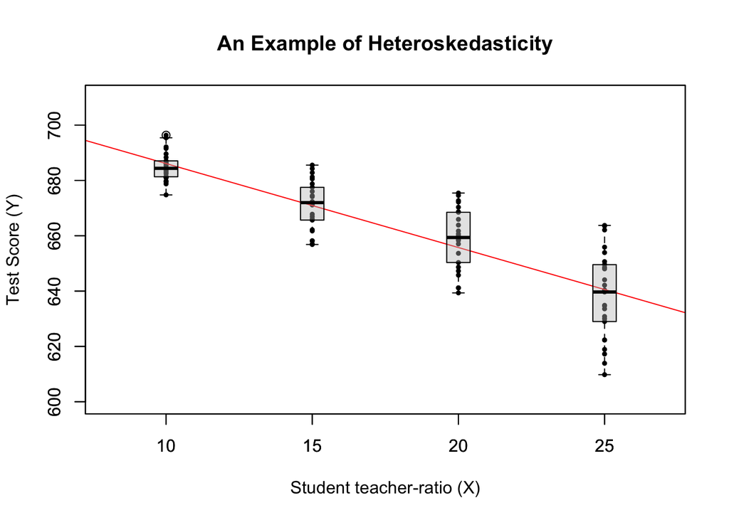

```r
library(scales)

# Genrate some heteroskedastic data

set.seed(123)
x <- rep(c(10,15,20,25),each=25)
e <- rnorm(100, sd=12)
i <- order(runif(100, max=dnorm(e, sd=12)))
y <- 720 - 3.3 * x + e[rev(i)]

# Plot data and inspect conditional distributions

mod <- lm(y ~ x)
plot(x, y, main="An Example of Heteroskedasticity",
     xlab = "Student teacher-ratio (X)",
     ylab = "Test Score (Y)",
     cex=0.5, pch=19, xlim=c(8,27), ylim=c(600,710))
abline(mod, col="red")
boxplot(y~x, add=TRUE, at=c(10,15,20,25), col=alpha("gray", 0.4), border="black")
```

In this example, it is straightforward to see that we face unequal conditional variances. Specifically, the variance of the test score (and therefore $var(u_i|X=x)$) increases with $X$.

### Should we care about heteroskedasticity?

First, let us see how $SE(\hat{\beta}_1)$ is computed under the assumption of homoskedasticity. The `summary` function uses the homoskedasticity-only formula
$$SE(\hat{\beta}_1) = \sqrt{ \overset{\sim}{\sigma}^2_{beta_1} } = \sqrt{ \frac{SER^2}{\sum(X_i - \overline{X})^2} }.$$

This in fact is an estimator for the standard deviation of the estimator $\hat{\beta}_1$ that is inconsistent for the true value $SE(\hat{\beta}_1)$. The implication is that $t$-statistics computed in the manner of key concept 5.1 do not have a standard normal distribution, even in large samples. This issue may invalidate inference drawn from the previously treated tools for hypothesis testing.

We will now use R to compute the homoskedasticity-only standard error estimator for $\hat{\beta}_1$ by hand and see if it matches the value provided by `summary()`.

```r
# Store model summary in 'mod'
model <- summary(linear_model)

# Extract the standard error of the regression from model summary
SER <- model$sigma

# Compute the variation in 'tsratio'
V <- (nrow(CASchools)-1)*var(CASchools$tsratio)

# Compute the standard error of the slope parameter's estimator and print it
SE.beta_1.hat <- sqrt(SER^2/V); SE.beta_1.hat
```

```
## [1] 0.4798255
```

```r
# Use logical operators to see if the value computed by hand matches the one provided
# in mod$coefficients. Round estimates to four decimal places.

round(model$coefficients[2,2],4) == round(SE.beta_1.hat,4)
```

```
## [1] TRUE
```

Indeed, the estimated values are equal.

### Computation of heteroskedasticity-robust standard errors

Cosistent estimation of $SE(\hat{\beta}_1)$ under heteroskedasticity is granted when the following robust estimator is used.

$$SE(\hat{\beta}_1) = \sqrt{ \frac{ \frac{1}{n-2} \sum_{i=1}^n (X_i - \overline{X})^2 \hat{u}_i^2 }{ \left[ \frac{1}{n} \sum_{i=1}^n (X_i - \overline{X})^2 \right]^2} }$$

Stadard error estimates computed this way are also referred to as Eicker-Huber-White standard errors.

It can be quite cumbersome to do so this calculation by hand. Luckily, there are R function for that purpose. A convenient one, named `vcovHC` is contained in the `sandwich` package.

Let us now compute robust standard error estimates for coefficients in `linear_model`.

```r
library(sandwich)

vcov <- vcovHC(linear_model, type = "HC0")
vcov
```

```
##             (Intercept)    tsratio
## (Intercept)  106.908469 -5.3383689
## tsratio       -5.338369  0.2685841
```

The output is the variance-covariance matrix of coefficient estimates. We are interested in the square root of the diagonal elements of this matrix since these are the standard error estimates we seek:

```r
robust_se <- sqrt(diag(vcov))
robust_se
```

```
## (Intercept)     tsratio
##   10.339655    0.518251
```

Now assume we want to generate a coefficient summary that reports robust standard error estimates for coefficient estimates, robust $t$-statistics and corresponding $p$-values for the regression model `linear_model`. This can be done as follows:

```r
# We invoke the function `coeftest()` on our model. Further we specify in the argument `vcov.`
# that the Eicker-Huber-White estimator, "HC0", is to be used.

coeftest(linear_model, vcov. = vcovHC(linear_model, type = "HC0"))
```

```
##
## t test of coefficients:
##
##              Estimate Std. Error t value  Pr(>|t|)
## (Intercept) 698.93295   10.33966  67.597 < 2.2e-16 ***
## tsratio      -2.27981    0.51825  -4.399 1.382e-05 ***
## ---
## Signif. codes:  0 '***' 0.001 '**' 0.01 '*' 0.05 '.' 0.1 ' ' 1
```

We see that values reported in the column ‘Std. Error’ equal the ones received using `sqrt(diag(vcov))`.

### Key Concept 5.5

### The Gauss-Markov-Theorem for $\hat{\beta}_1$

Suppose the Assumptions made in Key Concept 4.3 hold *and* that the errors are *homoskedastic*. The OLS estimator is the best (in the sense of smallest variance) linear conditionally unbiased estimator (*BLUE*) in this setting.

Let us have a closer look at what this means:

- Estimators of $\beta_1$ that are linear functions of the $Y_1, \dots, Y_n$ and that are unbiased conditionally on the regressor $X_1, \dots, X_n$ can be written as
  $$\overset{\sim}{\beta}_1 = \sum_{i=1}^n a_i Y_i$$
  where the $a_i$ are weights that are allowed to depend on the $X_i$ but *not* on the $Y_i$.
- We already know that $\overset{\sim}{\beta}_1$ has a sampling distribution. If now
  $$E(\overset{\sim}{\beta}_1 | X_1, \dots, X_n) = \beta_1$$
  we say that $\overset{\sim}{\beta}_1$ is a linear unbiased estimator of $\beta_1$, conditionally on the $X_1, \dots, X_n$.
- We may ask if $\overset{\sim}{\beta}_1$ is also the *best* estimator in this class, i.e. the most efficient one. The weights $a_i$ play an important role here.

#### Example

Consider the case of a regression of $Y_i,\dots,Y_n$ on a constant. Here, the $Y_i$ are assumed to be a random sample from a population with mean $\mu$ and variance $\sigma^2$. We know that the OLS estimator is the sample mean:
$$\hat{\beta}_1 = \overline{\beta}_1 = \sum_{i=1}^n \underbrace{\frac{1}{n}}_{=a_i} Y_i$$

Clearly, each observation is weighted by $a_i = \frac{1}{n}$.

We also know that $Var(\hat{\beta}_1)=\frac{\sigma^2}{n}$.

We will now use R for a simulation study to illustrate what happens to the variance of the estimator if different weights
$$w_i = \frac{1 \pm \epsilon}{n}$$
are assigned to either half of the sample $Y_1, \dots, Y_n$.

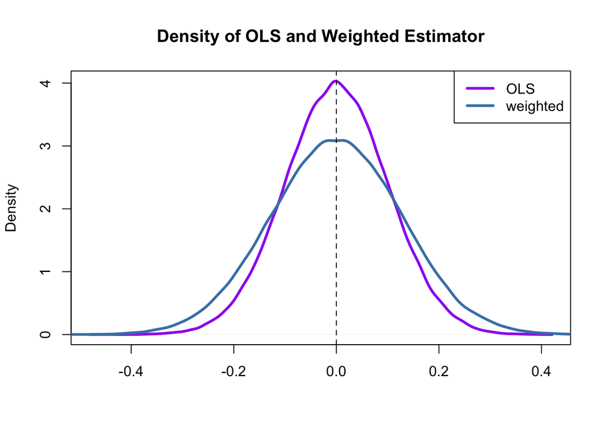

```r
# Set sample size and number of repititionas

n <- 100
reps <- 1e5

# Choose epsilon and create a vector of weights as defined above

epsilon <- 0.8
w <- c( rep((1+epsilon)/n,n/2), rep((1-epsilon)/n,n/2) )

# Draw random sample y_1,...,y_N from the standard normal distribution
# Compute both estimates 1e5 times and store the result in vectors

ols <- rep(NA,reps)
weightedestimator <- rep(NA,reps)

for (i in 1:reps)
{
  y <- rnorm(n)
  ols[i] <- mean(y)
  weightedestimator[i] <- crossprod(w,y)
}

# Plot estimates of the estimators distribution

plot(density(ols),col="purple", lwd=3, main="Density of OLS and Weighted Estimator",xlab="")
lines(density(weightedestimator),col="steelblue", lwd=3)
abline(v=0,lty=2)
legend('topright', c("OLS","weighted"), col=c("purple","steelblue"),lwd=3)
```

What conclusion can we draw from the result?

- Both estimators seem to be unbiased: The means of their estimated distributions are zero.
- The `weightedestimator` is less efficient than the `ols` estimator: There is higher dispersion when weights are $w_i = \frac{1 \pm \epsilon}{n}$ instead of $w_i=\frac{1}{n}$.

# Chapter 6

## Section 6.1 (Omitted Variable Bias)

## Section 6.3

```r
# Multiple Regression - Application to Test Scores and the Student-Teacher Ratio
library(AER)                                                    # contains the dataset
data(CASchools)
CASchools$tsratio  <- CASchools$students/CASchools$teachers     # teacher-student-ratio
CASchools$score    <- (CASchools$read + CASchools$math)/2       # average test-score
model <- lm(score ~ tsratio + english, data = CASchools)
```

## Section 6.4

Taking the code from Section 6.3 you could simply use `summary(model)` to print the $SER$, $R^2$ and adjusted-$R^2$. You find them at the bottom of the output.

```r
summary(model)
```

```
##
## Call:
## lm(formula = score ~ tsratio + english, data = CASchools)
##
## Residuals:
##     Min      1Q  Median      3Q     Max
## -48.845 -10.240  -0.308   9.815  43.461
##
## Coefficients:
##              Estimate Std. Error t value Pr(>|t|)
## (Intercept) 686.03224    7.41131  92.566  < 2e-16 ***
## tsratio      -1.10130    0.38028  -2.896  0.00398 **
## english      -0.64978    0.03934 -16.516  < 2e-16 ***
## ---
## Signif. codes:  0 '***' 0.001 '**' 0.01 '*' 0.05 '.' 0.1 ' ' 1
##
## Residual standard error: 14.46 on 417 degrees of freedom
## Multiple R-squared:  0.4264, Adjusted R-squared:  0.4237
## F-statistic:   155 on 2 and 417 DF,  p-value: < 2.2e-16
```

You can also compute the parameters by hand using the formulas on p. 242.

```r
n <- nrow(CASchools)    # number of observations (rows)
k <- 2                  # 2 regressors
y_mean <- mean(CASchools$score)

SSR <- sum( residuals(model)^2 )
TSS <- sum( ( CASchools$score - y_mean )^2 )
ESS <- sum((fitted(model) - y_mean)^2)

SER <- sqrt(1/(n-k-1) * SSR)
Rsq <- 1 - (SSR / TSS)
adj_Rsq <- 1 - (n-1)/(n-k-1) * SSR/TSS
cat(SER, Rsq, adj_Rsq, sep = "    ")
```

```
## 14.46448    0.4264315    0.4236805
```

## Section 6.7

### Examples of Perfect Multicollinearity

If you use `lm` to estimate a model with a set of regressors that suffer from perfect multicollinearity the system will warn you (*1 not defined because of singularities*) and ignore the regressor(s) which is(are) assumed to be a linear combination of the others.

```r
# Example 1
library(AER)                                                    # contains the dataset
data(CASchools)
CASchools$tsratio  <- CASchools$students/CASchools$teachers     # teacher-student-ratio
CASchools$score    <- (CASchools$read + CASchools$math)/2       # average test-score
CASchools$FracEL    <- CASchools$english/100
model <- lm(score ~ tsratio + english + FracEL, data = CASchools)
summary(model)
```

```
##
## Call:
## lm(formula = score ~ tsratio + english + FracEL, data = CASchools)
##
## Residuals:
##     Min      1Q  Median      3Q     Max
## -48.845 -10.240  -0.308   9.815  43.461
##
## Coefficients: (1 not defined because of singularities)
##              Estimate Std. Error t value Pr(>|t|)
## (Intercept) 686.03224    7.41131  92.566  < 2e-16 ***
## tsratio      -1.10130    0.38028  -2.896  0.00398 **
## english      -0.64978    0.03934 -16.516  < 2e-16 ***
## FracEL             NA         NA      NA       NA
## ---
## Signif. codes:  0 '***' 0.001 '**' 0.01 '*' 0.05 '.' 0.1 ' ' 1
##
## Residual standard error: 14.46 on 417 degrees of freedom
## Multiple R-squared:  0.4264, Adjusted R-squared:  0.4237
## F-statistic:   155 on 2 and 417 DF,  p-value: < 2.2e-16
```

If you compute OLS by hand you will run into the problem as well but noone is helping you out. The computation simply fails. Why is this the case? Take the following example:

Note: In this special case the nominator equals zero as well. Can you show that?

```r
# Example 2
library(AER)                                                    # contains the dataset
data(CASchools)
CASchools$tsratio  <- CASchools$students/CASchools$teachers     # teacher-student-ratio
CASchools$score    <- (CASchools$read + CASchools$math)/2       # average test-score
CASchools$NVS      <- ifelse(CASchools$tsratio < 12, 0, 1)      # if tsratio smaller 12, NVS = 0, else NVS = 1
model <- lm(score ~ tsratio + english + NVS, data = CASchools)
summary(model)
```

```
##
## Call:
## lm(formula = score ~ tsratio + english + NVS, data = CASchools)
##
## Residuals:
##     Min      1Q  Median      3Q     Max
## -48.845 -10.240  -0.308   9.815  43.461
##
## Coefficients: (1 not defined because of singularities)
##              Estimate Std. Error t value Pr(>|t|)
## (Intercept) 686.03224    7.41131  92.566  < 2e-16 ***
## tsratio      -1.10130    0.38028  -2.896  0.00398 **
## english      -0.64978    0.03934 -16.516  < 2e-16 ***
## NVS                NA         NA      NA       NA
## ---
## Signif. codes:  0 '***' 0.001 '**' 0.01 '*' 0.05 '.' 0.1 ' ' 1
##
## Residual standard error: 14.46 on 417 degrees of freedom
## Multiple R-squared:  0.4264, Adjusted R-squared:  0.4237
## F-statistic:   155 on 2 and 417 DF,  p-value: < 2.2e-16
```

```r
# Example 3
library(AER)                                                    # contains the dataset
data(CASchools)
CASchools$tsratio  <- CASchools$students/CASchools$teachers  # teacher-student-ratio
CASchools$score    <- (CASchools$read + CASchools$math)/2  # average test-score
CASchools$PctES    <- 100 - CASchools$english  # Percentage of english speakers
model <- lm(score ~ tsratio + english + PctES, data = CASchools)
summary(model)
```

```
##
## Call:
## lm(formula = score ~ tsratio + english + PctES, data = CASchools)
##
## Residuals:
##     Min      1Q  Median      3Q     Max
## -48.845 -10.240  -0.308   9.815  43.461
##
## Coefficients: (1 not defined because of singularities)
##              Estimate Std. Error t value Pr(>|t|)
## (Intercept) 686.03224    7.41131  92.566  < 2e-16 ***
## tsratio      -1.10130    0.38028  -2.896  0.00398 **
## english      -0.64978    0.03934 -16.516  < 2e-16 ***
## PctES              NA         NA      NA       NA
## ---
## Signif. codes:  0 '***' 0.001 '**' 0.01 '*' 0.05 '.' 0.1 ' ' 1
##
## Residual standard error: 14.46 on 417 degrees of freedom
## Multiple R-squared:  0.4264, Adjusted R-squared:  0.4237
## F-statistic:   155 on 2 and 417 DF,  p-value: < 2.2e-16
```

## Excursus: The Weak Law of Large Numbers

# Chapter 7

## Section 7.2

Testing joint hypothesis in a multiple regression framework.

### Key Concept 7.1

### Testing the hypothesis $\beta_j = \beta_{j,0}$ against the alternative $\beta_j \neq \beta_{j,0}$

1. Compute the standard error of $\hat{\beta_j}$
2. Compute the t-statistic,
   $$t = \frac{\hat{\beta}_j - \beta_{j,0}} {SE(\hat{\beta_j})}$$
3. Compute the p-value,
   $$p-value = 2 \phi(-|t^{act}|)$$

where $t^{act}$ is the value of the t-statistic actually computed. Reject the hypothesis at the 5% significance level if the p-value is less than $0.05$ or, equivalently, if $|t^{act}| > 1.96$. The standard error and (typically) the t-statistic and p-value testing $\beta_j = 0$ are computed automativally by statistical software.

### Key Concept 7.2

### Confidence Intervals for a single coefficient in multipe regression

A $95\%$ two-sided confidence interval for coefficient $\beta_j$ is an interval that contains the true value of $\beta_j$ with a $95 \%$ probability; that is, it contains the true value of $\beta_j$ in $95 \%$ of all randomly drawn samples. Equivalently, it is the set of values of $\beta_j$ that cannot be rejected by a $5 \%$ two-sided hypothesis test. When the sample size is large, the $95 \%$ confidence interval for $\beta_j$ is
$$[\hat{\beta_j}- 1.96 SE(\hat{\beta}_j), \hat{\beta_j} + 1.96 SE(\hat{\beta_j})]$$

## Application to Test Scores and the Student-Teacher Ratio

Let us take a look at the regression in section 6.3 again.

```r
# Confidence Intervals - Application to Test Scores and the Student-Teacher Ratio
model <- lm(score ~ tsratio + english, data = CASchools)
summary(model)
```

```
##
## Call:
## lm(formula = score ~ tsratio + english, data = CASchools)
##
## Residuals:
##     Min      1Q  Median      3Q     Max
## -48.845 -10.240  -0.308   9.815  43.461
##
## Coefficients:
##              Estimate Std. Error t value Pr(>|t|)
## (Intercept) 686.03224    7.41131  92.566  < 2e-16 ***
## tsratio      -1.10130    0.38028  -2.896  0.00398 **
## english      -0.64978    0.03934 -16.516  < 2e-16 ***
## ---
## Signif. codes:  0 '***' 0.001 '**' 0.01 '*' 0.05 '.' 0.1 ' ' 1
##
## Residual standard error: 14.46 on 417 degrees of freedom
## Multiple R-squared:  0.4264, Adjusted R-squared:  0.4237
## F-statistic:   155 on 2 and 417 DF,  p-value: < 2.2e-16
```

### Key Concept 7.3

### Omitted variable bias in multiple regression

Omitted Variable bias is the bias in the OLS estimator that arises when one or more included regressors are correlated with an omitted variable. For omitted variable bias to arise, twho things must be true:

1. At least one of the included regressors mut be correlated with the omitted variable
2. The omitted variable must be a determinant of the dependent variable, $Y$.

# Chapter 8 Nonlinear Regression Functions

Until now, it was assumed the regression funtion to be linear, i.e. the slope of the regression function was constant, implying that the level of $X$ has no influence on the effect a one unit change in $X$ induces in $Y$. If we want the effect of a change in $X$ on $Y$ to depend on the value of $X$, we have to use a nonlinear regression function.

Let us have a look at an example where using a nonlinear regression function might be better to decribe a relationship rather than a linear function: The relation between District Income and Test Score.

First, we compute correlation between both variables.

```r
cor(CASchools$income, CASchools$score)
```

```
## [1] 0.7124308
```

We see that the correlation coefficient is about $0.71$. Can we use this to assess wether a linear OLS regression line does fit the data adequately? Hardly. To see this, let us visualize the data and add a linear regression line to the plot.

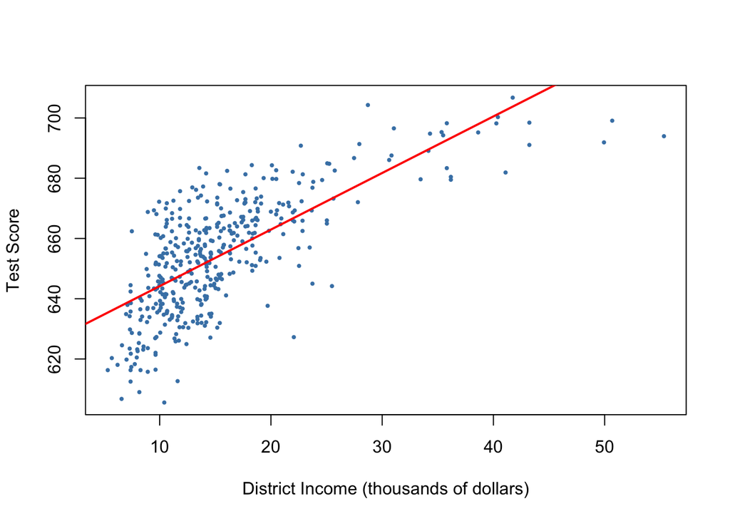

Figure 8.1

```r
# Plot observations
plot(CASchools$income, CASchools$score, pch=19, cex=0.4, col = "steelblue", xlab="District Income (thousands of dollars)", ylab="Test Score")

# Estimate a linear model and add the regression line to the plot
abline(lm(CASchools$score ~ CASchools$income), col="red", lwd=2)
```

Clearly, the fit is pretty bad. The relation does not seem to be a straight line. A better way to approximate the ideal line is use a quatratic function modeling test scores as a function of income and the square of income.

$$TestScore_i = \beta_0 + \beta_1 Income_i + \beta_2 Income_i^2 + u_i$$

The previously stated equation is called the *quadratic regression model*.

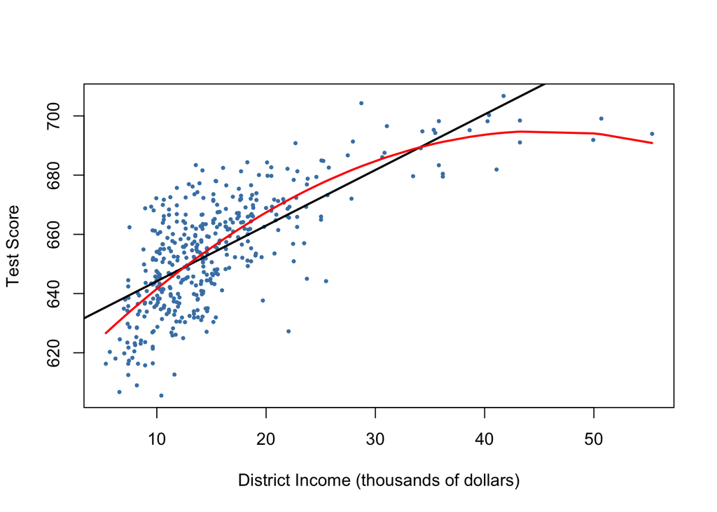

Figure 8.2

```r
# Plot observations
plot(CASchools$income, CASchools$score, pch=19, cex=0.4, col = "steelblue", xlab="District Income (thousands of dollars)", ylab="Test Score")

# Estimate a quadratic regression model and add the line to the plot
abline(lm(CASchools$score ~ CASchools$income), col="black", lwd=2)

lines(sort(CASchools$income), fitted(lm(CASchools$score ~ CASchools$income + I(CASchools$income^2)))[order(CASchools$income)], type='l', col="red", lwd=2)
```

# About Urfite